# El impacto de la pandemia en el uso de las billeteras digitales en Lima Metropolitana, mayo de 2023

### 3.4. Variables continuas

**Análisis 1: Gasto promedio diario pre-pandemia con el método principal de pago**

```r
round(porcentaje_gasto_manipulado, 2) # Porcentaje de las personas con gasto menor a 200 (para filtrar datos atípicos). De esta manera, corroboramos (por cantidad de personas) la validez del análisis.
```

```
## [1] 0.93
```

Se gráfica la densidad de la variable para observar el comportamiento que tiene y tratar de ver qué modelo es el que mejor se ajusta a lo obtenido.

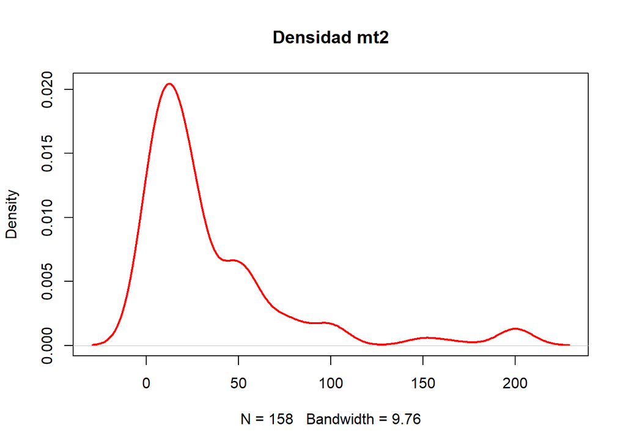

```r
plot(density(df_gasto_manipulado$`Gasto promedio diario pre-pandemia con método principal de pago`), lwd = 2, col = "red", main = "Densidad mt2")
```

Partiremos de la base que la gráfica tiene una aproximación a la distribución de probabilidad normal (debido a la forma), ya que no se asemeja ni a una exponencial ni a una uniforme.

Validación de la suposición de partida (corroboración de parámetros):

```r
de <- sd(df_gasto_manipulado$`Gasto promedio diario pre-pandemia con método principal de pago`, na.rm = TRUE)
media <- mean(df_gasto_manipulado$`Gasto promedio diario pre-pandemia con método principal de pago`, na.rm=TRUE)
# Media
round(media, 2)
```

```
## [1] 34.68
```

```r
# Mediana
median(df_gasto_manipulado$`Gasto promedio diario pre-pandemia con método principal de pago`, na.rm=TRUE)
```

```
## [1] 20
```

- La media y la mediana varían ni tienen un valor relativamente cercano. Por lo tanto, va en contra de una característica principal de una distribución normal (media = mediana).

```r
# Esperanza
round(integrate(function(x) dnorm(x,mean=media,sd=de)*x, lower=0, upper=200)[[1]][1], 2)
```

```
## [1] 39.66
```

```r
round(media, 2)
```

```
## [1] 34.68
```

- La esperanza calculada a partir del modelo de distribución normal tiene una pequeña diferencia con el de los datos. Esto puede interpretarse a favor de la suposición que se tomó.

```r
# Varianza
round(integrate(function(x) dnorm(x,mean=media,sd=de)*((x-de)^2), lower=0, upper=200)[[1]][1], 2)
```

```
## [1] 868.89
```

```r
round(var(df_gasto_manipulado$`Gasto promedio diario pre-pandemia con método principal de pago`,na.rm=TRUE), 2)
```

```
## [1] 1812.34
```

- La varianza calculada a partir de la distribución varía significativamente con la calculado a partir de los datos obtenidos, lo que debilita la suposición inicial.

Tras las validaciones, al ver parámetros que varían notablemente entre el modelo y lo registrado, podemos asumir que la distribución normal no es un modelo que se ajuste fielmente a la variable de estudio.

Como no cumple que sea una distribución normal, entonces se asumirá que la variable se comporta como una para el cálculo de probabilidades.

$$X \sim N(\mu,\sigma)$$

- **μ**: Esperanza
- **σ**: Desviación estándar
1. Calcular la probabilidad de que el gasto prepandemia diario sea menor que 50 soles

```r
round(pnorm(50, media, de), 2)
```

```
## [1] 0.64
```

2. Calcular la probabilidad de que el gasto prepandemia diario sea mayor a 100 soles

```r
round(1-pnorm(100,media,de), 2)
```

```
## [1] 0.06
```

**Análisis 2: Gasto promedio diario actual con el método principal de pago**

```r
round(porcentaje_gasto_actual_manipulado, 2) # Porcentaje de las personas con gasto menor a 200 (para filtrar datos atípicos). De esta manera, corroboramos (por cantidad de personas) la validez del análisis.
```

```
## [1] 0.91
```

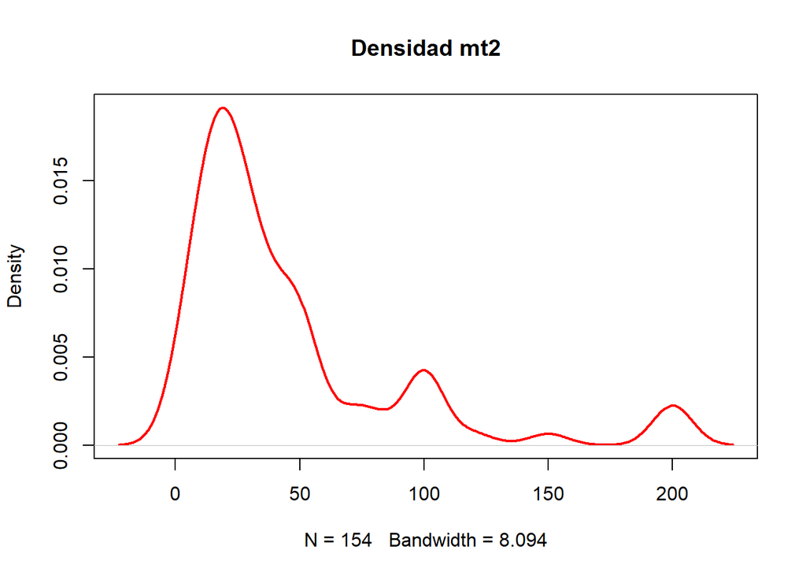

```r
plot(density(df_gasto_actual_manipulado$`Gasto promedio diario actual con método principal de pago`), lwd = 2, col = "red", main = "Densidad mt2")
```

Partiremos de la base que la gráfica tiene una aproximación a la distribución de probabilidad normal (debido a la forma), ya que no se asemeja ni a una exponencial ni a una uniforme.

Validación de la suposición de partida (corroboración de parámetros):

```r
de_a <- sd(df_gasto_actual_manipulado$`Gasto promedio diario actual con método principal de pago`, na.rm = TRUE)
media_a <- mean(df_gasto_actual_manipulado$`Gasto promedio diario actual con método principal de pago`, na.rm=TRUE)
# Media
round(media_a, 2)
```

```
## [1] 45.31
```

```r
# Mediana
median(df_gasto_actual_manipulado$`Gasto promedio diario actual con método principal de pago`, na.rm=TRUE)
```

```
## [1] 30
```

- La media y la mediana varían ni tienen un valor relativamente cercano. Por lo tanto, va en contra de una característica principal de una distribución normal (media = mediana).

```r
# Esperanza
round(integrate(function(x) dnorm(x,mean=media_a,sd=de_a)*x, lower=0, upper=200)[[1]][1], 2)
```

```
## [1] 49.11
```

```r
round(media_a, 2)
```

```
## [1] 45.31
```

- La esperanza calculada a partir del modelo de distribución normal tiene una pequeña diferencia con el de los datos. Esto puede interpretarse a favor de la suposición que se tomó.

```r
# Varianza
round(integrate(function(x) dnorm(x,mean=media_a,sd=de_a)*((x-de_a)^2), lower=0, upper=200)[[1]][1], 2)
```

```
## [1] 1229.34
```

```r
round(var(df_gasto_actual_manipulado$`Gasto promedio diario actual con método principal de pago`,na.rm=TRUE), 2)
```

```
## [1] 2089.59
```

- La varianza calculada a partir de la distribución varía significativamente con la calculado a partir de los datos obtenidos, lo que debilita la suposición inicial.

Tras las validaciones, al ver parámetros que varían notablemente entre el modelo y lo registrado, podemos asumir que la distribución normal no es un modelo que se ajuste fielmente a la variable de estudio.

Como no cumple que sea una distribución normal, entonces se asumirá que la variable se comporta como una para el cálculo de probabilidades.

$$X \sim N(\mu,\sigma)$$

- **μ**: Esperanza
- **σ**: Desviación estándar
1. Calcular la probabilidad de que el gasto actual diario sea menor que 50 soles

```r
round(pnorm(50, media_a, de_a), 2)
```

```
## [1] 0.54
```

2. Calcular la probabilidad de que el gasto actual diario sea mayor a 100 soles

```r
round(1-pnorm(100,media_a,de_a), 2)
```

```
## [1] 0.12
```